# assessment_brown_part1

**Q:** You roll a fair 6-sided dice iteratively until the sum of the dice rolls is greater than or equal to M. What is the mean and standard deviation of (sum - M) if M = 1e1, 1e2, 1e3, 1e4, and 1e5? What is the mean and standard deviation of the number of rolls if M = 1e1, 1e2, 1e3, 1e4, and 1e5? Please report the run time of your code and what efforts you made to optimize it. For example you could prepare a brute-force naive approach, report the run time, and then optimize it and measure how the runtime improved.

**A:** To find the mean and standard deviation of (sum - M), first we want to know the possible occurrences of the sum. The iteration repeats until the sum is greater than or equal to M. Therefore, we know that there are six possible cases, which is M, M+1, M+2, ..., M+5. Mathematically, it can be expressed as follows. The summation $S_n$ is equal to the value of $X_1, X_2, ..., X_n$, or

$$ S_n = \sum_{i=1}^{n}X_i$$

where $n$ is the total number of rolls. The iteration stops at $S_n \geq M$. The probability of getting M as final sum is

\begin{align} P(S_n = M) & = P(S_{n-1}=M-6 \text{ with } X_{n} = 6 ) \\ & + P(S_{n-1}=M-5 \text{ with } X_{n} = 5 ) \\ & + P(S_{n-1}=M-4 \text{ with } X_{n} = 4 ) \\ & + P(S_{n-1}=M-3 \text{ with } X_{n} = 3 ) \\ & + P(S_{n-1}=M-2 \text{ with } X_{n} = 2 ) \\ & + P(S_{n-1}=M-1 \text{ with } X_{n} = 1 ) \\ & = \frac{1}{6}\sum_{i}^6 P(S_{n-1}=M-i) \end{align}

Likewise, the probability of getting M+1, ..., M+5 is

\begin{align} P(S_n = M+1) & = \frac{1}{6}\sum_{i}^5 P(S_{n-1}=M-i) \\ P(S_n = M+2) & = \frac{1}{6}\sum_{i}^4 P(S_{n-1}=M-i) \\ P(S_n = M+3) & = \frac{1}{6}\sum_{i}^3 P(S_{n-1}=M-i) \\ P(S_n = M+4) & = \frac{1}{6}\sum_{i}^2 P(S_{n-1}=M-i) \\ P(S_n = M+5) & = \frac{1}{6}\sum_{i}^1 P(S_{n-1}=M-i) \\ \end{align}

Conceptually, the above equation could be iterated to the initial conditions. Or, the iteration can move forward from its initial condition until the desired steps. The initial conditions are

$$P(S_0) = 1; \quad P(S_{k})=0, \: k = -1, -2, -3, ...$$

The first couple cases can be written as

\begin{align} P(S_0) & = 1 \\ P(S_1) & = \frac{1}{6}*(P(S_0)) \\ P(S_2) & = \frac{1}{6}*(P(S_0)+P(S_1)) \\ P(S_3) & = \frac{1}{6}*(P(S_0)+P(S_1)+P(S_2)) \\ P(S_4) & = \frac{1}{6}*(P(S_0)+P(S_1)+P(S_2)+P(S_3)) \\ P(S_5) & = \frac{1}{6}*(P(S_0)+P(S_1)+P(S_2)+P(S_3)+P(S_4)) \\ P(S_6) & = \frac{1}{6}*(P(S_0)+P(S_1)+P(S_2)+P(S_3)+P(S_4)+P(S_5)) \\ P(S_7) & = \frac{1}{6}*(\phantom{P(S_0)+}\,P(S_1)+P(S_2)+P(S_3)+P(S_4)+P(S_5)+P(S_6)) \\ P(S_8) & = \frac{1}{6}*(\phantom{P(S_0)+P(S_1)+}\, P(S_2)+P(S_3)+P(S_4)+P(S_5)+P(S_6)+P(S_7)) \\ \end{align}

Due to the weighted factor ($\frac{1}{6}$), the probability at larger $M$, the summation of previous probabilities, is being smooth out. For large $M$, $P(S_{n-1}=M-i) \: i=1,2,3,4,5,6$ should be equally probable. This is shown in the following plot (Plateau region).

Therefore for the determined $M$, the corresponding probability ratio from $P(S_n = M)$ to $P(S_n = M+5)$ equal 6:5:4:3:2:1, with sum equals 1.

```python
import numpy as np
import matplotlib.pyplot as plt

## (summation - M) probability
def sum_minus_M_prob(M):
    possible_cases =  np.zeros(M+6)
    possible_cases[0] = 1.0
    ratio = 1./6  ## fair 6-sided dice
    for i in range(0,M):
         possible_cases[i+1:i+7] += ratio*possible_cases[i]
    return possible_cases[-6:]  ## return last six cases
```

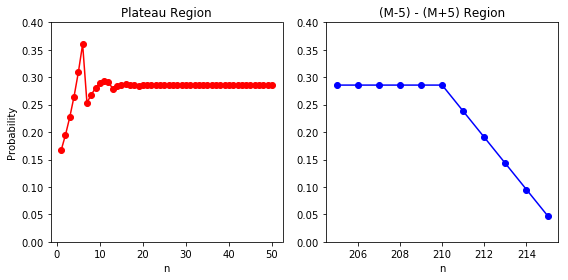

```python
## plateau region
M = 210
plateau_case =  np.zeros(M+6)
plateau_case[0] = 1.0
ratio = 1./6  ## fair 6-sided dice
for i in range(0,M):
    plateau_case[i+1:i+7] += ratio*plateau_case[i]
x_array = np.arange(0,M+6)

plt.close("all")
fig, ax = plt.subplots(1, 2, figsize=(8, 4))

ax[0].plot(x_array[1:51], plateau_case[1:51],'-o', color='red')
ax[0].set_ylim(top=0.4)
ax[0].set_ylim([0, 0.4])

ax[0].set_xlabel('n')
ax[0].set_ylabel('Probability')
ax[0].set_title('Plateau Region')
ax[1].plot(x_array[-11:], plateau_case[-11:],'-o', color='blue')
ax[1].set_xlabel('n')
ax[1].set_ylim(top=0.4)
ax[1].set_ylim([0, 0.4])

ax[1].set_title('(M-5) - (M+5) Region')

plt.tight_layout()
plt.show()
```

```python
# Print possibility of (sum - M)
from decimal import Decimal
def print_M(sci_notation, print_this = True):
    M = int(sci_notation)
    m_at_each_case = sum_minus_M_prob(M)

    m_x_array = np.arange(0,M+6)
    m_x_array = m_x_array[-6:]
    if print_this:
        print ("(sum - {:.0e}) prob. is {}".format(Decimal(sci_notation), m_at_each_case))
    return m_x_array, m_at_each_case

m_to_mplus5 = np.arange(0,6)
print ("The value of (sum - M) is {}".format(m_to_mplus5))
m1_x, m1 = print_M(1e0)
m10_x, m10 = print_M(1e1)
m100_x, m100 = print_M(1e2)
m1000_x, m1000 = print_M(1e3)
m10000_x, m10000 = print_M(1e4)
m100000_x, m100000 = print_M(1e5)
```

```
The value of (sum - M) is [0 1 2 3 4 5]
(sum - 1e+0) prob. is [ 0.16666667  0.16666667  0.16666667  0.16666667  0.16666667  0.16666667]
(sum - 1e+1) prob. is [ 0.28928846  0.24517838  0.19371662  0.13367789  0.09141049  0.04672816]
(sum - 1e+2) prob. is [ 0.28571429  0.23809524  0.19047619  0.14285714  0.0952381   0.04761905]
(sum - 1e+3) prob. is [ 0.28571429  0.23809524  0.19047619  0.14285714  0.0952381   0.04761905]
(sum - 1e+4) prob. is [ 0.28571429  0.23809524  0.19047619  0.14285714  0.0952381   0.04761905]
(sum - 1e+5) prob. is [ 0.28571429  0.23809524  0.19047619  0.14285714  0.0952381   0.04761905]
```

```python
print ("The ratio of 6:5:4:3:2:1 is:")
print (["{:.4f}".format(i / sum([6,5,4,3,2,1])) for i in range(6, 0, -1)])
```

```
The ratio of 6:5:4:3:2:1 is:
['0.2857', '0.2381', '0.1905', '0.1429', '0.0952', '0.0476']
```

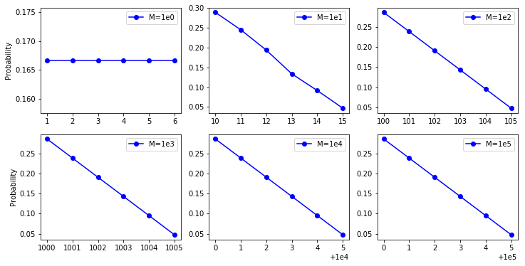

```python
#import matplotlib.pyplot as plt
plt.close("all")
fig, (axtop, axbot) = plt.subplots(2, 3, figsize=(12, 6))
axtop[0].plot(m1_x, m1, '-o', label="M=1e0", color='blue')
axtop[0].legend(loc=0)
axtop[1].plot(m10_x, m10, '-o', label="M=1e1", color='blue')
axtop[1].legend(loc=0)
axtop[2].plot(m100_x, m100, '-o', label="M=1e2", color='blue')
axtop[2].legend(loc=0)
axbot[0].plot(m1000_x, m1000, '-o', label="M=1e3", color='blue')
axbot[0].legend(loc=0)
axbot[1].plot(m10000_x, m10000, '-o', label="M=1e4", color='blue')
axbot[1].legend(loc=0)
axbot[2].plot(m100000_x, m100000, '-o', label="M=1e5", color='blue')
axbot[2].legend(loc=0)

axtop[0].set_ylabel('Probability')
axbot[0].set_ylabel('Probability')
plt.show()
```

```python
# Compute mean and standard deviation from the value and corresponding probability
def find_mean_standarddev(value, probability):
    mean = np.multiply(value, probability).sum()
    variance = sum((value - mean) ** 2 * probability)

    standarddev = np.sqrt(variance)
    return mean, standarddev

print ("The mean and standard deviation of (sum-M):")
#print (find_mean_sumMinusM(m_to_mplus5, m1))
print (find_mean_standarddev(m_to_mplus5, m10))
print (find_mean_standarddev(m_to_mplus5, m100))
print (find_mean_standarddev(m_to_mplus5, m1000))
print (find_mean_standarddev(m_to_mplus5, m10000))
print (find_mean_standarddev(m_to_mplus5, m100000))
```

```
The mean and standard deviation of (sum-M):
(1.6329280522055831, 1.4790076720180754)
(1.6666666666666863, 1.4907119849998607)
(1.6666666666666627, 1.4907119849998582)
(1.6666666666666627, 1.4907119849998582)
(1.6666666666666627, 1.4907119849998582)
```

The mean and standard deviation of (sum - M) is as follows.

| M | Mean | Standard Deviaation |
| --- | --- | --- |
| 1e1 | 1.633 | 1.480 |
| 1e2 | 1.667 | 1.491 |
| 1e3 | 1.667 | 1.491 |
| 1e4 | 1.667 | 1.491 |
| 1e5 | 1.667 | 1.491 |

### What is the mean and standard deviation of the number of rolls if M = 1e1, 1e2, 1e3, 1e4, and 1e5?

The number of ways to obtain the sum of rolls equals $M$ from six-sided dice is determined by the coefficient of the polynomial:

$$ (x^1 + x^2 + x^3 + x^4 + x^5 + x^6)^n = (\sum_{i=1}^{6}x^i)^n $$

where $n$ equals the number of rolls. The minimal possible $n$ is the smallest integer value greater than or equal to $M/6$. The maximum possible $n$ is $M$, where you have the sequence of 1 for every draw.

For example, if we want to find the sum of rolls equals or larger than 4 (M=4), we have all the possible situations as follows.

| n | possible sum of rolls | desired sum of rolls |
| --- | --- | --- |
| 1 | [1,2,..., 6] | [4,5,6] |
| 2 | [2,3,...,12] | [4,5,...,12] |
| 3 | [3,4,...,18] | [4,5,...,18] |
| 4 | [4,5,...,24] | [4,5,...,24] |

The probability of succeeded at $n^{th}$ draw is the probability of getting $n \geq M$ at current draw times the probability of summation smaller than $M$ at $(n-1)^{th}$ draw. Once we find the number of rolls and corresponding possibility, it is straightforward to compute mean and standard deviation. However, this approach is not computational desirable.

### Brute force method

```python
## %%timeit
import numpy as np
import math

## coefficients of the polynomial represent the number of possible
six_sided_dice = np.poly1d([1,1,1,1,1,1])

def find_prob_at_n_roll_sumM(num_of_rolls, M):
    ## find the index to collect S_n < M
    smaller_than_M_number = int(M-num_of_rolls)
    total_at_n = 6 ** num_of_rolls
    ## we count the num_of_rolls < M
    ## then do the subtraction at the end
    if (num_of_rolls < M):
        coeff_outcome = (six_sided_dice ** num_of_rolls).coef[-smaller_than_M_number:]
    else:
        coeff_outcome = [0]
    sum_of_larger_tham_M = total_at_n - sum(coeff_outcome)

    ## we return the value of total possible cases at n,
    ## and the cases S_n >= M
    return total_at_n, sum_of_larger_tham_M

def find_mean_and_standard_dev(M):
    ## minimum n_of_rolls can reach M
    minimum_rolls = math.ceil(M/6)
    ## dictionary for keys (k): number of rolls,
    ## values(v): probability
    dict_nRolls_prob = {}
    ## initialize previous failure
    prob_fail_at_previous_step = 0

    if M > 6:
        dict_nRolls_prob = {1: 0}
        prob_fail_at_previous_step = 1
    else:
        dict_nRolls_prob = {1: 1./6*(6-M+1)}
        prob_fail_at_previous_step = 1./6*(M-1)

    ## for loop for all the possible trials
    for curr_num_of_rolls in range(minimum_rolls, M+1):
        total_at_n, sum_of_larger_tham_M = find_prob_at_n_roll_sumM(curr_num_of_rolls, M)
        you_made_it_at_step_n = sum_of_larger_tham_M/total_at_n
        ## prob_success_at_n * prob_failed_at_n-1
        dict_nRolls_prob[curr_num_of_rolls] = you_made_it_at_step_n * prob_fail_at_previous_step
        prob_fail_at_previous_step *= (1 - you_made_it_at_step_n)


#         if prob_fail_at_previous_step < 1e-8:
#             print (curr_num_of_rolls)
#             break
        #print (curr_num_of_rolls, prob_fail_at_previous_step)

    ## find the mean
    mean_n_of_rolls = sum([ k * v  for k, v in dict_nRolls_prob.items() ])
    ## find the standard deviation

    standard_dev =  np.sqrt( sum([ (k-mean_n_of_rolls) ** 2 * v for k, v in dict_nRolls_prob.items() ]) )

    return dict_nRolls_prob, mean_n_of_rolls, standard_dev

if __name__ == '__main__':
    M = 10
    dict_nRolls_prob, mean_n_of_rolls, standard_dev = find_mean_and_standard_dev(M)
    #print (dict_nRolls_prob)
    print ("The mean of M = {} is {:.4f}".format(M, mean_n_of_rolls))
    print ("The standard deviation of M = {} is {:.4f}".format(M, standard_dev))

## 100 loops, best of 3: 5.56 ms per loop using %%timeit
```

```
The mean of M = 10 is 3.1767
The standard deviation of M = 10 is 0.7359
```

It takes about 5.56 ms to compute M = 10 in average using built-in timing method ("%%timeit"). Using such approach gives the result in reasonable time until M goes above 80. The error message shows that "overflow encountered in long*scalars". I can imagine that the computation becomes very heavy on getting the coefficient of$(\sum*{i=1}^{6}x^i)^n $ while $n$ goes very large. Therefore, dynamic programming approach comes to rescue.

### Dynamic programming approach

```python
## %%timeit
import numpy as np

def sum_to_smaller_than_M(amount):

    ## initialize the possible cases with size amount [1, 1, 1, 1, 1, 1, ...]
    ## dict_nRolls_cases: keys: number of rolls, values: smaller than M cases
    ## dict_nRolls_prob_greater_eq_M : keys: number of rolls, values: prob. greater or equal to M
    prob_fail_at_previous_step = 0
    ways_of_n_prev = [1 if i < 6 else 0 for i in range(amount)]
    ways_of_n_curr = [0] * (amount)

    if amount > 6:
        dict_nRolls_cases = {1: 6}
        dict_nRolls_prob_greater_eq_M = {1: 0}
        prob_fail_at_previous_step = 1
    else:
        dict_nRolls_cases = {1: amount}
        dict_nRolls_prob_greater_eq_M = {1: 1./6*(6-amount+1)}
        prob_fail_at_previous_step = 1./6*(amount-1)
    ## the pattern to find all the possible cases
    for curr_n_of_rolls in range(2, amount+1):
        all_less_than_M_cases = 1
        ## for each starting point, there is only one way (all 1s) to make S_n = number of rolls
        ways_of_n_curr[0] = 1
        for higher_amount_index in range(1, amount):
            higher_amount_indexMinus1 = higher_amount_index - 1

            if higher_amount_index < 6:
                ways_of_n_curr[higher_amount_index] = ways_of_n_curr[higher_amount_indexMinus1]\
                                                    + ways_of_n_prev[higher_amount_index]
            else:
                ways_of_n_curr[higher_amount_index] = ways_of_n_curr[higher_amount_indexMinus1]\
                                                    + ways_of_n_prev[higher_amount_index]      \
                                                    - ways_of_n_prev[higher_amount_index - 6]
            if higher_amount_index < amount - curr_n_of_rolls:
                all_less_than_M_cases += ways_of_n_curr[higher_amount_index]

        dict_nRolls_cases[curr_n_of_rolls] = all_less_than_M_cases
        dict_nRolls_prob_greater_eq_M[curr_n_of_rolls] = prob_fail_at_previous_step*(6**curr_n_of_rolls-all_less_than_M_cases)/(6**curr_n_of_rolls)

        # you fail at all the previous steps
        prob_fail_at_previous_step *= (1/6)**(curr_n_of_rolls)*(all_less_than_M_cases)

        ## update (sway) the current to previous list
        ways_of_n_prev, ways_of_n_curr = ways_of_n_curr, [0] * (amount)


    ## find the mean
    mean_n_of_rolls = sum([ k * v  for k, v in dict_nRolls_prob_greater_eq_M.items() ])
    ## find the standard deviation
    standard_dev =  np.sqrt( sum([ (k-mean_n_of_rolls) ** 2 * v \
                                  for k, v in dict_nRolls_prob_greater_eq_M.items() ]   ) )

    return dict_nRolls_prob_greater_eq_M, mean_n_of_rolls, standard_dev

if __name__ == '__main__':
    M = 10
    dict_nRolls_prob_greater_eq_M, mean_n_of_rolls, standard_dev = sum_to_smaller_than_M(M)
    ##print (dict_nRolls_prob_greater_eq_M)
    print ("The mean of M = {} is {:.4f}".format(M, mean_n_of_rolls))
    print ("The standard deviation of M = {} is {:.4f}".format(M, standard_dev))
    ## 1000 loops, best of 3: 976 µs per loop

    print ("-" * 50)
    M = 100
    dict_nRolls_prob_greater_eq_M, mean_n_of_rolls, standard_dev = sum_to_smaller_than_M(M)
    print ("The mean of M = {} is {:.4f}".format(M, mean_n_of_rolls))
    print ("The standard deviation of M = {} is {:.4f}".format(M, standard_dev))

    print ("-" * 50)
    M = 300
    dict_nRolls_prob_greater_eq_M, mean_n_of_rolls, standard_dev = sum_to_smaller_than_M(M)
    print ("The mean of M = {} is {:.4f}".format(M, mean_n_of_rolls))
    print ("The standard deviation of M = {} is {:.4f}".format(M, standard_dev))
```

```
The mean of M = 10 is 3.1767
The standard deviation of M = 10 is 0.7359
--------------------------------------------------
The mean of M = 100 is 27.5366
The standard deviation of M = 100 is 1.7305
--------------------------------------------------
The mean of M = 300 is 82.4670
The standard deviation of M = 300 is 2.7695
```

| M | mean | standard deviation |
| --- | --- | --- |
| 1e1 | 3.18 | 0.74 |
| 1e2 | 27.54 | 1.73 |

I reexamine the code and realize the error is due to the large value arithmetic. The computer can handle extremely large number, say $6^{1000}$, but not the $\frac{5^{1000}}{6^{1000}}$. Therefore, natural log arithmetic was implemented in the following code for calculating probability, and if-condition was utilized for skipping the cases of saving insignificant probability (Note: We still have to compute the probability).

In order to save some computational time, one might consider skipping steps at certain criteria. For example, at any given $M$ it is required to roll the die from 1, 2, ..., up to $M$ to calculate the probability.

> ```
>     if log_all_less_than_M_cases > log_all_num_of_rolls + math.log(0.9999):
> ```

The snippet is equivalent to the scenario at $n-$th draw

$$\frac{S_n < M}{\sum{S_n}} > 99.99 \%,$$

However, such term is being negligible only if $M$ is relatively small. One could easily evaluate the error propagation using logarithm function. While $M$ goes from $10^3$ to $10^4$, the error would go from 10% to 64%.

```python
## %%timeit

import numpy as np
import math

def large_number_division(numerator, denominator):
    ## we want to know y = p/q
    ## log(y) = log(p) - log(q)
    log_y = math.log(numerator) - math.log(denominator)
    return math.exp(log_y)

def sum_to_smaller_than_M(amount):

    ## initialize the possible cases with size amount [1, 1, 1, 1, 1, 1, ...]
    ## dict_nRolls_cases: keys: number of rolls, values: smaller than M cases
    ## dict_nRolls_prob_greater_eq_M : keys: number of rolls, values: prob. greater or equal to M
    prob_fail_at_previous_step = 0
    ways_of_n_prev = [1 if i < 6 else 0 for i in range(amount)]
    ways_of_n_curr = [0] * (amount)

    if amount > 6:
        dict_nRolls_cases = {1: 6}
        dict_nRolls_prob_greater_eq_M = {1: 0}
        prob_fail_at_previous_step = 1
    else:
        dict_nRolls_cases = {1: amount}
        dict_nRolls_prob_greater_eq_M = {1: 1./6*(6-amount+1)}
        prob_fail_at_previous_step = 1./6*(amount-1)
    ## the pattern to find all the possible cases
    ##doing_this = 0
    ##doing_that = 0
    for curr_n_of_rolls in range(2, amount):
        all_less_than_M_cases = 1
        ## for each starting point, there is only one way (all 1s) to make S_n = number of rolls
        ways_of_n_curr[0] = 1
        for higher_amount_index in range(1, amount):
            higher_amount_indexMinus1 = higher_amount_index - 1

            if higher_amount_index < 6:
                ways_of_n_curr[higher_amount_index] = ways_of_n_curr[higher_amount_indexMinus1]\
                                                    + ways_of_n_prev[higher_amount_index]
            else:
                ways_of_n_curr[higher_amount_index] = ways_of_n_curr[higher_amount_indexMinus1]\
                                                    + ways_of_n_prev[higher_amount_index]      \
                                                    - ways_of_n_prev[higher_amount_index - 6]
            if higher_amount_index < amount - curr_n_of_rolls:
                all_less_than_M_cases += ways_of_n_curr[higher_amount_index]

        dict_nRolls_cases[curr_n_of_rolls] = all_less_than_M_cases


        all_num_of_rolls = 6**curr_n_of_rolls

        log_all_num_of_rolls = math.log(all_num_of_rolls)
        log_all_less_than_M_cases = math.log(all_less_than_M_cases)

        ## if the probability is less than 0.1%, skip the calculation.
        if log_all_less_than_M_cases > log_all_num_of_rolls + math.log(0.9999):
        ##if 1 < 0:
            #print ("{}. Go next".format(curr_n_of_rolls))
            ##doing_this += 1
            next
        else:
            num_p = all_num_of_rolls-all_less_than_M_cases
            dict_nRolls_prob_greater_eq_M[curr_n_of_rolls] = prob_fail_at_previous_step*large_number_division(num_p,all_num_of_rolls)
        # you fail at all the previous steps
        prob_fail_at_previous_step *= (large_number_division(all_less_than_M_cases,all_num_of_rolls))
        #print (curr_n_of_rolls, prob_fail_at_previous_step)
        ##doing_that += 1

        ## update (sway) the current to previous list
        ways_of_n_prev, ways_of_n_curr = ways_of_n_curr, [0] * (amount)

    #for key ,value in dict_nRolls_cases.items():
    #    print (key, value)
    ## find the mean
    mean_n_of_rolls = sum([ k * v  for k, v in dict_nRolls_prob_greater_eq_M.items() ])
    ## find the standard deviation
    standard_dev =  np.sqrt( sum([ (k-mean_n_of_rolls) ** 2 * v \
                                  for k, v in dict_nRolls_prob_greater_eq_M.items() ]   ) )

    return dict_nRolls_prob_greater_eq_M, mean_n_of_rolls, standard_dev

if __name__ == '__main__':

#     M = 10
#     dict_nRolls_prob_greater_eq_M, mean_n_of_rolls, standard_dev = sum_to_smaller_than_M(M)
#     #print (dict_nRolls_prob_greater_eq_M)
#     print ("The mean of M = {} is {:.4f}".format(M, mean_n_of_rolls))
#     print ("The standard deviation of M = {} is {:.4f}".format(M, standard_dev))

    print ("-" * 50)
    M = 1000
    dict_nRolls_prob_greater_eq_M, mean_n_of_rolls, standard_dev = sum_to_smaller_than_M(M)
    #print (dict_nRolls_prob_greater_eq_M)
    print ("The mean of M = {} is {:.4f}".format(M, mean_n_of_rolls))
    print ("The standard deviation of M = {} is {:.4f}".format(M, standard_dev))

#     print ("-" * 50)
#     M = 1000
#     dict_nRolls_prob_greater_eq_M, mean_n_of_rolls, standard_dev = sum_to_smaller_than_M(M)
#     #print (dict_nRolls_prob_greater_eq_M)
#     print ("The mean of M = {} is {:.4f}".format(M, mean_n_of_rolls))
#     print ("The standard deviation of M = {} is {:.4f}".format(M, standard_dev))
```

```
--------------------------------------------------
The mean of M = 1000 is 277.0828
The standard deviation of M = 1000 is 4.6764
```

| M | mean | standard deviation | execution time |
| --- | --- | --- | --- |
| 1e1 | 3.18 | 0.74 | 115 µs |
| 1e2 | 27.54 | 1.73 | 7.98 ms |
| 1e3 | 277.08 | 4.68 | 925 ms |
| 1e4 | 2796.64 | 23.07 | 178.28 s |

**Note:** The reported execution time is calculated without printing information.

For $M \leq 1e4$, the calculation can be performed using my personal laptop. However, it is not feasible for larger $M$. The $M \geq 1e4$ case was performed using BECAT, the local facility at University of Connecticut.

### Reference

- https://www.dataquest.io/blog/jupyter-notebook-tips-tricks-shortcuts/
- https://stats.stackexchange.com/questions/145621/roll-a-6-sided-die-until-the-total-geq-m-mean-amount-by-which-m-is-exceede